# Self-Driving Car Engineer Nanodegree

## Project: Build a Traffic Sign Recognition Classifier

In this notebook, a template is provided for you to implement your functionality in stages, which is required to successfully complete this project. If additional code is required that cannot be included in the notebook, be sure that the Python code is successfully imported and included in your submission if necessary.

In addition to implementing code, there is a writeup to complete. The writeup should be completed in a separate file, which can be either a markdown file or a pdf document. There is a [write up template](https://github.com/udacity/CarND-Traffic-Sign-Classifier-Project/blob/master/writeup_template.md) that can be used to guide the writing process. Completing the code template and writeup template will cover all of the [rubric points](https://review.udacity.com/#!/rubrics/481/view) for this project.

The [rubric](https://review.udacity.com/#!/rubrics/481/view) contains "Stand Out Suggestions" for enhancing the project beyond the minimum requirements. The stand out suggestions are optional. If you decide to pursue the "stand out suggestions", you can include the code in this Ipython notebook and also discuss the results in the writeup file.

> **Note:** Code and Markdown cells can be executed using the **Shift + Enter** keyboard shortcut. In addition, Markdown cells can be edited by typically double-clicking the cell to enter edit mode.

## Step 0: Load The Data

```python
%%javascript
IPython.OutputArea.prototype._should_scroll = function(lines) {
    return false;
}
// No output shrinking
```

```python
# Load pickled data
import pickle

training_file = 'data/train.p'
validation_file = 'data/valid.p'
testing_file = 'data/test.p'
own_testing_file = 'data/test_own.p'

with open(training_file, mode='rb') as f:
    train = pickle.load(f)
with open(validation_file, mode='rb') as f:
    valid = pickle.load(f)
with open(testing_file, mode='rb') as f:
    test = pickle.load(f)
with open(own_testing_file, mode='rb') as f:
    X_test_own = pickle.load(f)
y_test_own = [13,40,13,38,1,28,17,35,25,33,12,3,13,0,0,38]

X_train, y_train = train['features'], train['labels']
X_valid, y_valid = valid['features'], valid['labels']
X_test, y_test = test['features'], test['labels']
```

## Step 1: Dataset Summary & Exploration

The pickled data is a dictionary with 4 key/value pairs:

- `'features'` is a 4D array containing raw pixel data of the traffic sign images, (num examples, width, height, channels).
- `'labels'` is a 1D array containing the label/class id of the traffic sign. The file `signnames.csv` contains id -> name mappings for each id.
- `'sizes'` is a list containing tuples, (width, height) representing the original width and height the image.
- `'coords'` is a list containing tuples, (x1, y1, x2, y2) representing coordinates of a bounding box around the sign in the image. **THESE COORDINATES ASSUME THE ORIGINAL IMAGE. THE PICKLED DATA CONTAINS RESIZED VERSIONS (32 by 32) OF THESE IMAGES**

Complete the basic data summary below. Use python, numpy and/or pandas methods to calculate the data summary rather than hard coding the results. For example, the [pandas shape method](http://pandas.pydata.org/pandas-docs/stable/generated/pandas.DataFrame.shape.html) might be useful for calculating some of the summary results.

### Provide a Basic Summary of the Data Set Using Python, Numpy and/or Pandas

```python
import numpy as np

# Number of training examples
n_train = len(y_train)

# Number of validation examples
n_validation = len(y_valid)

# Number of testing examples.
n_test = len(y_test)

# Number of own testing examples.
n_test_own = len(X_test_own)

# What's the shape of an traffic sign image?
image_shape = X_train.shape[1:]

# How many unique classes/labels there are in the dataset.
n_classes = len(np.unique(y_train))

print("Number of training examples =", n_train)
print("Number of validation examples =", n_validation)
print("Number of testing examples =", n_test)
print("Number of own testing examples =", n_test_own)
print("Image data shape =", image_shape)
print("Number of classes =", n_classes)
```

```
Number of training examples = 34799
Number of validation examples = 4410
Number of testing examples = 12630
Number of own testing examples = 16
Image data shape = (32, 32, 3)
Number of classes = 43
```

### Include an exploratory visualization of the dataset

Visualize the German Traffic Signs Dataset using the pickled file(s). This is open ended, suggestions include: plotting traffic sign images, plotting the count of each sign, etc.

The [Matplotlib](http://matplotlib.org/) [examples](http://matplotlib.org/examples/index.html) and [gallery](http://matplotlib.org/gallery.html) pages are a great resource for doing visualizations in Python.

**NOTE:** It's recommended you start with something simple first. If you wish to do more, come back to it after you've completed the rest of the sections. It can be interesting to look at the distribution of classes in the training, validation and test set. Is the distribution the same? Are there more examples of some classes than others?

```
10 random images from the TRAIN dataset with corresponding labels.
```

[figure not shown]

```
1 image per class from the TRAIN dataset with corresponding labels.
```

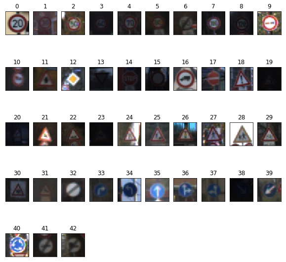

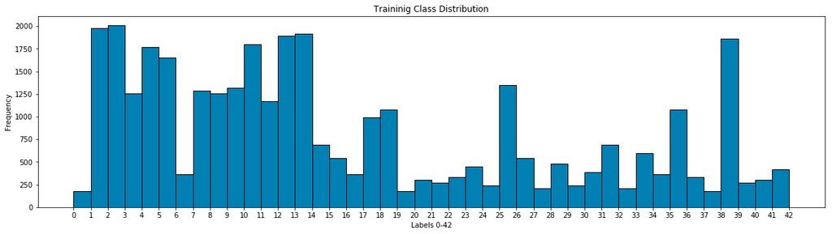

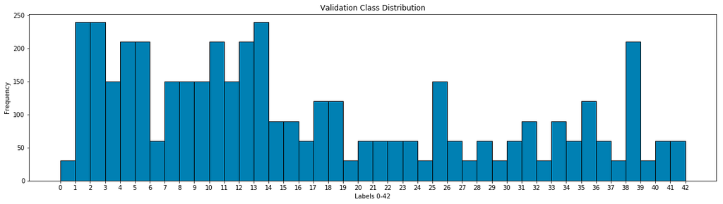

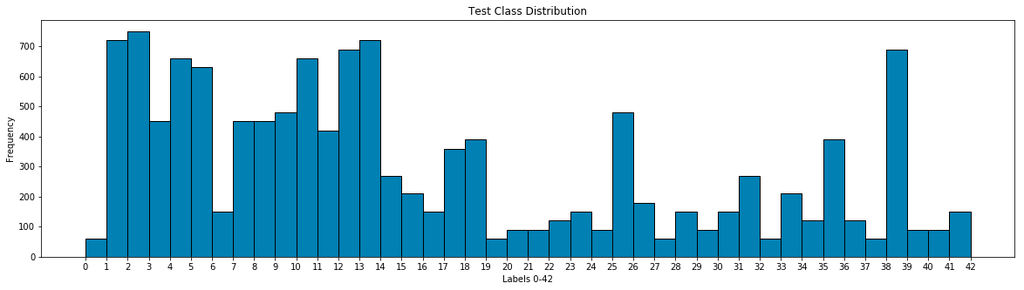

```
Frequency table of train data set.
```

| ClassId | SignName | Frequency |
| --- | --- | --- |
| 0 | Speed limit (20km/h) | 180 |
| 37 | Go straight or left | 180 |
| 19 | Dangerous curve to the left | 180 |
| 32 | End of all speed and passing limits | 210 |
| 27 | Pedestrians | 210 |
| 41 | End of no passing | 210 |
| 42 | End of no passing by vehicles over 3.5 metric ... | 210 |
| 24 | Road narrows on the right | 240 |
| 29 | Bicycles crossing | 240 |
| 39 | Keep left | 270 |
| 21 | Double curve | 270 |
| 40 | Roundabout mandatory | 300 |
| 20 | Dangerous curve to the right | 300 |
| 36 | Go straight or right | 330 |
| 22 | Bumpy road | 330 |
| 6 | End of speed limit (80km/h) | 360 |
| 16 | Vehicles over 3.5 metric tons prohibited | 360 |
| 34 | Turn left ahead | 360 |
| 30 | Beware of ice/snow | 390 |
| 23 | Slippery road | 450 |
| 28 | Children crossing | 480 |
| 26 | Traffic signals | 540 |
| 15 | No vehicles | 540 |
| 33 | Turn right ahead | 599 |
| 14 | Stop | 690 |
| 31 | Wild animals crossing | 690 |
| 17 | No entry | 990 |
| 18 | General caution | 1080 |
| 35 | Ahead only | 1080 |
| 11 | Right-of-way at the next intersection | 1170 |
| 3 | Speed limit (60km/h) | 1260 |
| 8 | Speed limit (120km/h) | 1260 |
| 7 | Speed limit (100km/h) | 1290 |
| 9 | No passing | 1320 |
| 25 | Road work | 1350 |
| 5 | Speed limit (80km/h) | 1650 |
| 4 | Speed limit (70km/h) | 1770 |
| 10 | No passing for vehicles over 3.5 metric tons | 1800 |
| 38 | Keep right | 1860 |
| 12 | Priority road | 1890 |
| 13 | Yield | 1920 |
| 1 | Speed limit (30km/h) | 1980 |
| 2 | Speed limit (50km/h) | 2010 |

```python
### Data exploration visualization code goes here.
import random
import matplotlib.pyplot as plt
import pandas as pd

# Visualizations will be shown in the notebook.
%matplotlib inline

# Display 10 random images from the `train` dataset
print("10 random images from the TRAIN dataset with corresponding labels.")
plt.figure(figsize=(10,10))
for i in range(10):
    plt.subplot(1,10,i+1)
    rand = random.randint(0,len(X_train))
    plt.xticks([])
    plt.yticks([])
    plt.imshow(X_train[rand])
    plt.title(y_train[rand])
plt.show()

# Display 1 image from each class from the `train` dataset
print("1 image per class from the TRAIN dataset with corresponding labels.")
plt.figure(figsize=(10,10))
for i in range(43):
    d = np.where(y_train == i)[0][0]
    plt.subplot(5,10,i+1)
    plt.title(y_train[d])
    plt.xticks([])
    plt.yticks([])
    plt.imshow(X_train[d])
plt.show()


# Display distribution of images per classes in the training/validation/test sets
def hist_distro(data_labels, name):
    fig, ax = plt.subplots(figsize=(20,5))
    counts, bins, patches = ax.hist(data_labels, color=(0,0.5,0.7), edgecolor = 'black', bins=np.unique(data_labels))
    ax.set_xticks(np.unique(bins))
    plt.title(name)
    plt.xlabel("Labels 0-42")
    plt.ylabel("Frequency")
    plt.show()

hist_distro(y_train, "Traininig Class Distribution")
hist_distro(y_valid, "Validation Class Distribution")
hist_distro(y_test, "Test Class Distribution")

# Frequency table of train data set
print("Frequency table of train data set.")
labels = pd.read_csv('signnames.csv', sep=',', index_col='ClassId')
unique, counts = np.unique(y_train, return_counts=True)

labels['Frequency'] = list(counts)
labels.sort_values('Frequency')
```

## Step 2: Design and Test a Model Architecture

Design and implement a deep learning model that learns to recognize traffic signs. Train and test your model on the [German Traffic Sign Dataset](http://benchmark.ini.rub.de/?section=gtsrb&subsection=dataset).

The LeNet-5 implementation shown in the classroom at the end of the CNN lesson is a solid starting point. You'll have to change the number of classes and possibly the preprocessing, but aside from that it's plug and play!

With the LeNet-5 solution from the lecture, you should expect a validation set accuracy of about 0.89. To meet specifications, the validation set accuracy will need to be at least 0.93. It is possible to get an even higher accuracy, but 0.93 is the minimum for a successful project submission.

There are various aspects to consider when thinking about this problem:

- Neural network architecture (is the network over or underfitting?)
- Play around preprocessing techniques (normalization, rgb to grayscale, etc)
- Number of examples per label (some have more than others).
- Generate fake data.

Here is an example of a [published baseline model on this problem](http://yann.lecun.com/exdb/publis/pdf/sermanet-ijcnn-11.pdf). It's not required to be familiar with the approach used in the paper but, it's good practice to try to read papers like these.

### Pre-process the Data Set (normalization, grayscale, etc.)

Minimally, the image data should be normalized so that the data has mean zero and equal variance. For image data, `(pixel - 128)/ 128` is a quick way to approximately normalize the data and can be used in this project.

Other pre-processing steps are optional. You can try different techniques to see if it improves performance.

Use the code cell (or multiple code cells, if necessary) to implement the first step of your project.

```python
def normalize(image_data, a=0.1, b=0.9):
    """
    Normalize the image data with Min-Max scaling to a range of [0.1, 0.9]
    :param image_data: The image data to be normalized
    :return: Normalized image data
    """
    # Implement Min-Max scaling for image data
    return a + (((image_data-np.min(image_data)) * (b - a)) / (np.max(image_data) - np.min(image_data)))
```

```python
import cv2

# Histogram equalization of the R,G,B channels
def hist_equa(img):
    img_hist = img.copy()
    for channel in range(3):
        img_hist[:,:,channel] = cv2.equalizeHist(img_hist[:,:,channel])
    return img_hist

# Grayscale of the image
def gray(img):
    return  cv2.cvtColor(img, cv2.COLOR_BGR2GRAY)
```

```
15 random images from the TRAIN dataset with corresponding Histogram Equalization
```

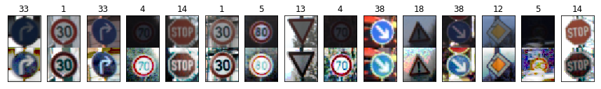

```
Same images in Grayscale
```

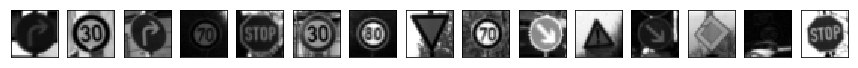

```python
### Further image manipulation of the train dataset, may be used later as input

print("15 random images from the TRAIN dataset with corresponding Histogram Equalization")
plt.figure(figsize=(15,15))
rand_list = []
for i in range(15):
    rand = random.randint(0,len(X_train))
    rand_list.append(rand)
    img = X_train[rand]
    img_hist = hist_equa(img)
    both = np.concatenate((img, img_hist), axis=0)
    plt.subplot(1,15,i+1)
    plt.xticks([])
    plt.yticks([])
    plt.title(y_train[rand])
    plt.imshow(X_train[rand])
    plt.imshow(both)
plt.show()

# Grayscale
print("Same images in Grayscale")
plt.figure(figsize=(15,15))
for i in range(15):
    img_gray = gray(X_train[rand_list[i]])
    plt.subplot(1,15,i+1)
    plt.xticks([])
    plt.yticks([])
    plt.imshow(img_gray, cmap='gray')
plt.show()
```

### Model Architecture

```python
### Define your architecture here.
### Feel free to use as many code cells as needed.
from tensorflow.contrib.layers import flatten
import tensorflow as tf

tf.reset_default_graph()
def LeNet(x, keep_prob, channel):

    mu = 0
    sigma = 0.1
    nb_classes = 43

    # Layer 1: Convolutional. Input = 32x32x3(/1). Output = 28x28x6.
    ## Weight and bias
    conv1_w = tf.Variable(tf.truncated_normal([5, 5, channel, 6],  mean = mu, stddev = sigma))
    conv1_b = tf.Variable(tf.zeros(6))
    ## Apply Convolution and add bias
    conv1_layer = tf.nn.conv2d(x, conv1_w, strides=[1, 1, 1, 1], padding='VALID') + conv1_b

    # Activation.
    conv1_layer = tf.nn.relu(conv1_layer)

    # Pooling. Input = 28x28x6. Output = 14x14x6.
    conv1_layer = tf.nn.max_pool(conv1_layer, ksize=[1, 2, 2, 1],
    strides=[1, 2, 2, 1], padding='VALID')

    # Layer 2: Convolutional. Output = 10x10x16.
    ## Weight and bias
    conv2_w = tf.Variable(tf.truncated_normal([5, 5, 6, 16],  mean = mu, stddev = sigma))
    conv2_b = tf.Variable(tf.zeros(16))
    ## Apply Convolution and add bias
    conv2_layer = tf.nn.conv2d(conv1_layer, conv2_w, strides=[1, 1, 1, 1], padding='VALID') + conv2_b

    # Activation.
    conv2_layer = tf.nn.relu(conv2_layer)

    # Pooling. Input = 10x10x16. Output = 5x5x16.
    conv2_layer = tf.nn.max_pool(conv2_layer, ksize=[1, 2, 2, 1],
    strides=[1, 2, 2, 1], padding='VALID')

    # Flatten. Input = 5x5x16. Output = 400.
    fc0   = flatten(conv2_layer)

    # Layer 3: Fully Connected. Input = 400. Output = 120.
    fc1_w = tf.Variable(tf.truncated_normal(shape=(400, 120), mean = mu, stddev = sigma))
    fc1_b = tf.Variable(tf.zeros(120))
    fc1   = tf.matmul(fc0, fc1_w) + fc1_b

    # Activation.
    fc1 = tf.nn.relu(fc1)
    fc1 = tf.nn.dropout(fc1, keep_prob)

    # Layer 4: Fully Connected. Input = 120. Output = 84.
    fc2_w = tf.Variable(tf.truncated_normal(shape=(120, 84), mean = mu, stddev = sigma))
    fc2_b = tf.Variable(tf.zeros(84))
    fc2   = tf.matmul(fc1, fc2_w) + fc2_b

    # Activation.
    fc2 = tf.nn.relu(fc2)

    # Layer 5: Fully Connected. Input = 84. Output = 43.
    fc3_w = tf.Variable(tf.truncated_normal(shape=(84, nb_classes), mean = mu, stddev = sigma))
    fc3_b = tf.Variable(tf.zeros(nb_classes))
    logits   = tf.matmul(fc2, fc3_w) + fc3_b

    return logits
```

### Train, Validate and Test the Model

A validation set can be used to assess how well the model is performing. A low accuracy on the training and validation sets imply underfitting. A high accuracy on the training set but low accuracy on the validation set implies overfitting.

Let's start with training a plain LeNet-Network for 10 Epochs with the unchanged RGB-Images from the train dataset:

```python
# Visualize helper functions for analyze training performance

# Confusion matrix
def plot_confusion_matrix(cm):
    fig = plt.figure(figsize=(5, 5))
    ax = fig.add_subplot(111)
    cax = ax.matshow(cm, cmap=plt.cm.Oranges)
    fig.colorbar(cax)
    plt.title('Confusion Matrix')
    plt.xlabel('Predicted Classes')
    plt.ylabel('True Classes')
    plt.show()

def table_confusion_matrix(cm):
    label_corr = np.diag(cm)
    label_max = np.sum(cm, 0)
    unique, train_counts = np.unique(y_train, return_counts=True)

    labels = pd.read_csv('signnames.csv', sep=',', index_col='ClassId')
    cm_show = labels
    cm_show['Train images'] = train_counts
    cm_show['Validation images'] = label_max
    cm_show['Correct classified'] = label_corr
    cm_show['Percent correct'] = 100/label_max * label_corr
    cm_show['Falsly classified as (ClassId)'] = ""
    cm_show['Images falsly classified'] = ""

    for i in range(43):
         indices_up = np.where(cm[:i,i] != 0)[0]
         indices_down = np.where(cm[(i+1):,i] != 0)[0] + (i+1)
         indices = np.concatenate((indices_up, indices_down))
         indices_str = np.char.mod('%i', indices)
         indices_str = "| ".join(indices_str)
         cm_show.at[i, 'Falsly classified as (ClassId)'] = indices_str

         values_up = cm[:i,i][cm[:i,i] > 0]
         values_down = cm[(i+1):,i][cm[(i+1):,i] > 0]
         values = np.concatenate((values_up, values_down))
         values_str = np.char.mod('%i', values)
         values_str = "| ".join(values_str)
         cm_show.at[i, 'Falsly classified as (ClassId)'] = indices_str
         cm_show.at[i, 'Images falsly classified'] = values_str

    return cm_show

# Learning curve (train vs. vaLidation)
def plot_learning(train_acc_all, valid_acc_all):
    epochs = len(train_acc_all)

    plt.figure(figsize=(5, 5))
    plt.plot(range(epochs), train_acc_all, label='train')
    plt.plot(range(epochs), valid_acc_all, label='validation')
    plt.title('Learning Curve')
    plt.ylabel('Accuracy')
    plt.xlabel('Epochs')
    plt.xticks(range(epochs))
    plt.legend(loc='center left')
    plt.show()

def plot_loss(train_loss_all, valid_loss_all):
    epochs = len(train_loss_all)

    plt.figure(figsize=(5, 5))
    plt.plot(range(epochs), train_loss_all, label='train')
    plt.plot(range(epochs), valid_loss_all, label='validation')
    plt.title('Loss')
    plt.ylabel('Loss')
    plt.xlabel('Epochs')
    plt.xticks(range(epochs))
    plt.legend(loc='center left')
    plt.show()
```

```python
def evaluate(X_data, y_data):
    num_examples = len(X_data)
    total_accuracy, total_loss = 0, 0
    sess = tf.get_default_session()
    for offset in range(0, num_examples, BATCH_SIZE):
        batch_x, batch_y = X_data[offset:offset+BATCH_SIZE], y_data[offset:offset+BATCH_SIZE]
        accuracy, loss = sess.run([accuracy_operation, loss_operation], feed_dict={x: batch_x, y: batch_y,
                                                                                  keep_prob: keep_prob_value})
        total_accuracy += (accuracy * len(batch_x))
        total_loss += loss
    return (total_accuracy / num_examples), (total_loss / num_examples)
```

```python
from sklearn.utils import shuffle


# Train the model
def train_model(X_train, y_train, X_valid, y_valid, saver, save_path, early_stopping = False):
    if early_stopping:
        acc_act = 0.9
        epoch_act = 0
        print('Training with early stopping.')
    else:
        print('Training without early stopping.')

    with tf.Session() as sess:
        sess.run(tf.global_variables_initializer())
        num_examples = len(X_train)

        print("Training...")
        train_acc_all , valid_acc_all = [], []
        train_loss_all, valid_loss_all = [], []
        for i in range(EPOCHS):
            X_train, y_train = shuffle(X_train, y_train)
            for offset in range(0, num_examples, BATCH_SIZE):
                end = offset + BATCH_SIZE
                batch_x, batch_y = X_train[offset:end], y_train[offset:end]
                sess.run(training_operation, feed_dict={x: batch_x, y: batch_y, keep_prob: keep_prob_value})

            training_accuracy, training_loss = evaluate(X_train, y_train)
            validation_accuracy, validation_loss = evaluate(X_valid, y_valid)
            train_acc_all.append(training_accuracy)
            train_loss_all.append(training_loss)
            valid_acc_all.append(validation_accuracy)
            valid_loss_all.append(validation_loss)
            if i < 10:
                print("EPOCH {} ...".format(i+1))
                print("Training Accuracy = {:.3f}".format(training_accuracy))
                print("Training Loss = {:.5f}".format(training_loss))
                print("Validation Accuracy = {:.3f}".format(validation_accuracy))
                print("Validation Loss = {:.5f}".format(validation_loss))
            elif i % 10 == 9:
                print("EPOCH {} ...".format(i+1))
                print("Training Accuracy = {:.3f}".format(training_accuracy))
                print("Training Loss = {:.5f}".format(training_loss))
                print("Validation Accuracy = {:.3f}".format(validation_accuracy))
                print("Validation Loss = {:.5f}".format(validation_loss))
            if early_stopping:
                if acc_act < validation_accuracy:
                    acc_act = validation_accuracy
                    epoch_act = i+1
                    saver.save(sess, save_path)
                    print('Model saved with val_accuracy: ', acc_act, '  at EPOCH:  ', epoch_act)

        print()
        print('Max train accuracy: ', np.max(train_acc_all), 'at EPOCH: ', (np.where(train_acc_all==np.max(train_acc_all))[0][0])+1)
        print('Max validation accuracy: ', np.max(valid_acc_all), 'at EPOCH: ', (np.where(valid_acc_all==np.max(valid_acc_all))[0][0])+1)
        if not early_stopping:
            saver.save(sess, save_path)
            print("Model saved")
        else:
            print('Final model saved from epoch: ', epoch_act, '  with Validation accuracy: ', acc_act)
        saver.save(sess, './model_last2')

    return train_acc_all, train_loss_all, valid_acc_all, valid_loss_all
```

```python
# RGB normalized
X_train_plain = X_train.copy()
X_train_plain = normalize(X_train_plain)
X_valid_plain = X_valid.copy()
X_valid_plain = normalize(X_valid_plain)

# Other normalization codes:
## X_train=np.array([((i-128.0)/128.0) for i in X_train])
##    X_train = (X_train / 255.).astype(np.float32)


# Histogram equalization normalized
X_train_hist = X_train.copy()
X_valid_hist = X_valid.copy()
for i in range(len(X_train_hist)):
    X_train_hist[i] = hist_equa(X_train_hist[i])
for i in range(len(X_valid_hist)):
    X_valid_hist[i] = hist_equa(X_valid_hist[i])
X_train_hist = normalize(X_train_hist)
X_valid_hist = normalize(X_valid_hist)

# Grayscale normalized
X_train_gray = np.empty(X_train[:,:,:,0].shape)
X_valid_gray = np.empty(X_valid[:,:,:,0].shape)
for i in range(len(X_train_gray)):
    X_train_gray[i] = gray(X_train[i])
for i in range(len(X_valid_gray)):
    X_valid_gray[i] = gray(X_valid[i])
X_train_gray = np.uint8(X_train_gray[:,:,:,np.newaxis])
X_valid_gray = np.uint8(X_valid_gray[:,:,:,np.newaxis])
X_train_gray = normalize(X_train_gray)
X_valid_gray = normalize(X_valid_gray)

input_data_sets =  [
             ('RGBNormalized', 'lenet_1', X_train_plain, X_valid_plain),
             ('HistEquaNormalized', 'lenet_hist',  X_train_hist, X_valid_hist),
             ('GrayNormalized', 'lenet_gray', X_train_gray, X_valid_gray)
            ]
```

```
Training with  RGBNormalized images.
Training...
EPOCH 1 ...
Training Accuracy = 0.623
Training Loss = 0.00909
Validation Accuracy = 0.564
Validation Loss = 0.01157
EPOCH 2 ...
Training Accuracy = 0.884
Training Loss = 0.00285
Validation Accuracy = 0.786
Validation Loss = 0.00608
EPOCH 3 ...
Training Accuracy = 0.921
Training Loss = 0.00199
Validation Accuracy = 0.840
Validation Loss = 0.00468
EPOCH 4 ...
Training Accuracy = 0.917
Training Loss = 0.00219
Validation Accuracy = 0.827
Validation Loss = 0.00633
EPOCH 5 ...
Training Accuracy = 0.944
Training Loss = 0.00140
Validation Accuracy = 0.825
Validation Loss = 0.00588
EPOCH 6 ...
Training Accuracy = 0.964
Training Loss = 0.00091
Validation Accuracy = 0.864
Validation Loss = 0.00501
EPOCH 7 ...
Training Accuracy = 0.964
Training Loss = 0.00097
Validation Accuracy = 0.879
Validation Loss = 0.00422
EPOCH 8 ...
Training Accuracy = 0.957
Training Loss = 0.00103
Validation Accuracy = 0.861
Validation Loss = 0.00542
EPOCH 9 ...
Training Accuracy = 0.941
Training Loss = 0.00169
Validation Accuracy = 0.846
Validation Loss = 0.00648
EPOCH 10 ...
Training Accuracy = 0.968
Training Loss = 0.00079
Validation Accuracy = 0.881
Validation Loss = 0.00456

Max train accuracy:  0.967901376493 at EPOCH:  10
Max validation accuracy:  0.880725622556 at EPOCH:  10
Model saved
```

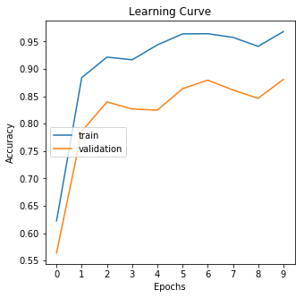

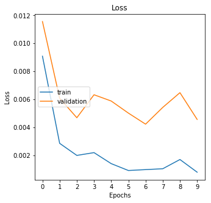

```
------------------------------------------------------------
Training with  HistEquaNormalized images.
Training...
EPOCH 1 ...
Training Accuracy = 0.817
Training Loss = 0.00440
Validation Accuracy = 0.766
Validation Loss = 0.00620
EPOCH 2 ...
Training Accuracy = 0.899
Training Loss = 0.00241
Validation Accuracy = 0.841
Validation Loss = 0.00438
EPOCH 3 ...
Training Accuracy = 0.923
Training Loss = 0.00182
Validation Accuracy = 0.875
Validation Loss = 0.00357
EPOCH 4 ...
Training Accuracy = 0.932
Training Loss = 0.00160
Validation Accuracy = 0.864
Validation Loss = 0.00388
EPOCH 5 ...
Training Accuracy = 0.924
Training Loss = 0.00183
Validation Accuracy = 0.849
Validation Loss = 0.00475
EPOCH 6 ...
Training Accuracy = 0.908
Training Loss = 0.00234
Validation Accuracy = 0.859
Validation Loss = 0.00462
EPOCH 7 ...
Training Accuracy = 0.943
Training Loss = 0.00141
Validation Accuracy = 0.885
Validation Loss = 0.00409
EPOCH 8 ...
Training Accuracy = 0.916
Training Loss = 0.00221
Validation Accuracy = 0.847
Validation Loss = 0.00568
EPOCH 9 ...
Training Accuracy = 0.958
Training Loss = 0.00100
Validation Accuracy = 0.903
Validation Loss = 0.00294
EPOCH 10 ...
Training Accuracy = 0.937
Training Loss = 0.00156
Validation Accuracy = 0.870
Validation Loss = 0.00457

Max train accuracy:  0.957987298486 at EPOCH:  9
Max validation accuracy:  0.902947845913 at EPOCH:  9
Model saved
```

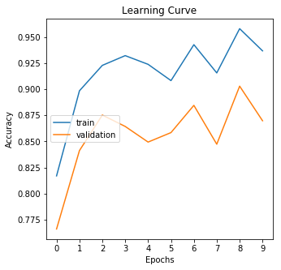

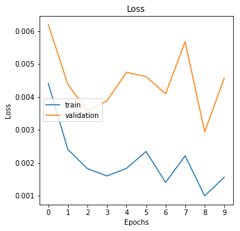

```
------------------------------------------------------------
Training with  GrayNormalized images.
Training...
EPOCH 1 ...
Training Accuracy = 0.836
Training Loss = 0.00429
Validation Accuracy = 0.768
Validation Loss = 0.00666
EPOCH 2 ...
Training Accuracy = 0.907
Training Loss = 0.00258
Validation Accuracy = 0.832
Validation Loss = 0.00537
EPOCH 3 ...
Training Accuracy = 0.927
Training Loss = 0.00187
Validation Accuracy = 0.842
Validation Loss = 0.00510
EPOCH 4 ...
Training Accuracy = 0.950
Training Loss = 0.00135
Validation Accuracy = 0.854
Validation Loss = 0.00598
EPOCH 5 ...
Training Accuracy = 0.961
Training Loss = 0.00102
Validation Accuracy = 0.874
Validation Loss = 0.00429
EPOCH 6 ...
Training Accuracy = 0.946
Training Loss = 0.00133
Validation Accuracy = 0.859
Validation Loss = 0.00471
EPOCH 7 ...
Training Accuracy = 0.970
Training Loss = 0.00081
Validation Accuracy = 0.877
Validation Loss = 0.00534
EPOCH 8 ...
Training Accuracy = 0.963
Training Loss = 0.00100
Validation Accuracy = 0.883
Validation Loss = 0.00513
EPOCH 9 ...
Training Accuracy = 0.952
Training Loss = 0.00126
Validation Accuracy = 0.861
Validation Loss = 0.00566
EPOCH 10 ...
Training Accuracy = 0.965
Training Loss = 0.00091
Validation Accuracy = 0.860
Validation Loss = 0.00674

Max train accuracy:  0.969941665042 at EPOCH:  7
Max validation accuracy:  0.88253968235 at EPOCH:  8
Model saved
```

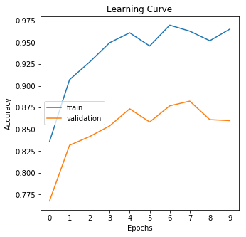

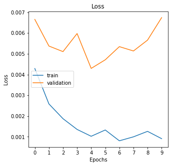

```python
### Calculate and report the accuracy on the training and validation set.
### Once a final model architecture is selected,
### the accuracy on the test set should be calculated and reported as well.
### Feel free to use as many code cells as needed.
import tensorflow as tf
import pathlib
from sklearn.utils import shuffle

nb_classes = 43 # Classes

# Hyperparameters
EPOCHS = 10
BATCH_SIZE = 128
l_rate = 0.01
keep_prob_value = 1 # Dropout


for data_set, save_name, X_train, X_valid in input_data_sets:
    pathlib.Path(save_name + '_model').mkdir(parents=True, exist_ok=True)
    save_path = save_name + '_model/' + save_name + '.ckpt'

    if data_set == 'GrayNormalized':
        channel = 1
    else:
        channel = 3
    # Placeholders
    x = tf.placeholder(tf.float32, (None, 32, 32, channel)) # Placeholder for train dataset
    y = tf.placeholder(tf.int32, (None)) # Placeholder for labels
    one_hot_y = tf.one_hot(y, nb_classes)
    keep_prob = tf.placeholder(tf.float32) # Placeholder for dropout value
    keep_prob_value = 1.0

    # Trainig pipeline
    logits = LeNet(x, keep_prob, channel)
    cross_entropy = tf.nn.softmax_cross_entropy_with_logits(labels=one_hot_y, logits=logits)
    loss_operation = tf.reduce_mean(cross_entropy)
    optimizer = tf.train.AdamOptimizer(learning_rate = l_rate)
    training_operation = optimizer.minimize(loss_operation)

    # Model evaluation
    correct_prediction = tf.equal(tf.argmax(logits, 1), tf.argmax(one_hot_y, 1))
    accuracy_operation = tf.reduce_mean(tf.cast(correct_prediction, tf.float32))

    print('Training with ', data_set, 'images.')
    saver = tf.train.Saver()
    train_acc_all, train_loss_all, valid_acc_all, valid_loss_all = train_model(X_train, y_train, X_valid, y_valid, saver, save_path)

    # Plot learning curves and loss
    plot_learning(train_acc_all, valid_acc_all)
    plot_loss(train_loss_all, valid_loss_all)
    print('-'*60)
```

From now on I sticked with the plain **RGB** images. After finding a good model, I will try training with the histogram equalized images again.  
In the following I state some improvement attempts on the LeNet-Architecture as well as on the different hyperparameters.  
Starting with doubling all filters in the convolution layers:  
6 -> 12 (Conv1)  
16 -> 32 (Conv2)

```python
### Define your architecture here.
### Feel free to use as many code cells as needed.
from tensorflow.contrib.layers import flatten
import tensorflow as tf

tf.reset_default_graph()
def LeNet2(x, keep_prob, mu=0, sigma=0.1, filter1=12, filter2=32, neurond1=120, neurond2=84, conv3 = False, activ0 = False, activ1 = False, activ2 = False):

    nb_classes = 43 # Classes
    # Layer 1: Convolutional. Input = 32x32x3. Output = 28x28xfilter1.
    ## Weight and bias
    conv1_w = tf.Variable(tf.truncated_normal([5, 5, 3, filter1], mean = mu, stddev = sigma))
    conv1_b = tf.Variable(tf.zeros(filter1))
    ## Apply Convolution and add bias
    conv1_layer = tf.nn.conv2d(x, conv1_w, strides=[1, 1, 1, 1], padding='VALID') + conv1_b

    # Activation.
    conv1_layer = tf.nn.relu(conv1_layer)
    if activ0:
        return conv1_layer
    # Pooling. Input = 28x28xfilter1. Output = 14x14xfilter1.
    conv1_layer = tf.nn.max_pool(conv1_layer, ksize=[1, 2, 2, 1],
    strides=[1, 2, 2, 1], padding='VALID')

    # Layer 2: Convolutional. Output = 10x10xfilter2.
    ## Weight and bias
    conv2_w = tf.Variable(tf.truncated_normal([5, 5, filter1, filter2],  mean = mu, stddev = sigma))
    conv2_b = tf.Variable(tf.zeros(filter2))
    ## Apply Convolution and add bias
    conv2_layer = tf.nn.conv2d(conv1_layer, conv2_w, strides=[1, 1, 1, 1], padding='VALID') + conv2_b

    # Activation.
    conv2_layer = tf.nn.relu(conv2_layer)
    if activ1:
        return conv2_layer

    # Pooling. Input = 10x10xfilter2. Output = 5x5xfilter2.
    conv2_layer = tf.nn.max_pool(conv2_layer, ksize=[1, 2, 2, 1],
    strides=[1, 2, 2, 1], padding='VALID')

    if conv3:
        # Layer 3: Convolutional. Output = 3x3xfilter2.
        ## Weight and bias
        conv3_w = tf.Variable(tf.truncated_normal([3, 3, filter2, filter2],  mean = mu, stddev = sigma))
        conv3_b = tf.Variable(tf.zeros(filter2))
        ## Apply Convolution and add bias
        conv3_layer = tf.nn.conv2d(conv2_layer, conv3_w, strides=[1, 1, 1, 1], padding='VALID') + conv3_b

        # Activation.
        conv3_layer = tf.nn.relu(conv3_layer)
        if activ2:
            return conv3_layer
        conv3_layer1 = tf.nn.dropout(conv3_layer, keep_prob)

        # Flatten. Input = 3x3xfilter2. Output = 3*3*filter2.
        fc0   = flatten(conv3_layer1)

        # Layer 3: Fully Connected. Input = 3*3*filter2. Output = neurond1.
        fc1_w = tf.Variable(tf.truncated_normal(shape=(3*3*filter2, neurond1), mean = mu, stddev = sigma))
        fc1_b = tf.Variable(tf.zeros(neurond1))
        fc1   = tf.matmul(fc0, fc1_w) + fc1_b

        # Activation.
        fc1 = tf.nn.relu(fc1)
        fc1 = tf.nn.dropout(fc1, keep_prob)


        # Layer 4: Fully Connected. Input = neurond1. Output = neurond2.
        fc2_w = tf.Variable(tf.truncated_normal(shape=(neurond1, neurond2), mean = mu, stddev = sigma))
        fc2_b = tf.Variable(tf.zeros(neurond2))
        fc2   = tf.matmul(fc1, fc2_w) + fc2_b

        # Activation.
        fc2 = tf.nn.relu(fc2)
        fc2 = tf.nn.dropout(fc2, keep_prob)

        # Layer 5: Fully Connected. Input = neurond2. Output = nb_classes(= 43).
        fc3_w = tf.Variable(tf.truncated_normal(shape=(neurond2, nb_classes), mean = mu, stddev = sigma))
        fc3_b = tf.Variable(tf.zeros(nb_classes))
        logits   = tf.matmul(fc2, fc3_w) + fc3_b

        return logits


    # Flatten. Input = 5x5xfilter2. Output = 5*5*filter2.
    fc0   = flatten(conv2_layer)

    # Layer 3: Fully Connected. Input = 5*5*filter2. Output = neurond1.
    fc1_w = tf.Variable(tf.truncated_normal(shape=(5*5*filter2, neurond1), mean = mu, stddev = sigma))
    fc1_b = tf.Variable(tf.zeros(neurond1))
    fc1   = tf.matmul(fc0, fc1_w) + fc1_b

    # Activation.
    fc1 = tf.nn.relu(fc1)
    fc1 = tf.nn.dropout(fc1, keep_prob)


    # Layer 4: Fully Connected. Input = neurond1. Output = neurond2.
    fc2_w = tf.Variable(tf.truncated_normal(shape=(neurond1, neurond2), mean = mu, stddev = sigma))
    fc2_b = tf.Variable(tf.zeros(neurond2))
    fc2   = tf.matmul(fc1, fc2_w) + fc2_b

    # Activation.
    fc2 = tf.nn.relu(fc2)
    fc2 = tf.nn.dropout(fc2, keep_prob)

    # Layer 5: Fully Connected. Input = neurond2. Output = nb_classes(= 43).
    fc3_w = tf.Variable(tf.truncated_normal(shape=(neurond2, nb_classes), mean = mu, stddev = sigma))
    fc3_b = tf.Variable(tf.zeros(nb_classes))
    logits   = tf.matmul(fc2, fc3_w) + fc3_b

    return logits
```

```
Training with  Model1 parameters.
Training...
EPOCH 1 ...
Training Accuracy = 0.917
Training Loss = 0.00208
Validation Accuracy = 0.837
Validation Loss = 0.00459
EPOCH 2 ...
Training Accuracy = 0.957
Training Loss = 0.00118
Validation Accuracy = 0.877
Validation Loss = 0.00397
EPOCH 3 ...
Training Accuracy = 0.957
Training Loss = 0.00110
Validation Accuracy = 0.887
Validation Loss = 0.00410
EPOCH 4 ...
Training Accuracy = 0.950
Training Loss = 0.00121
Validation Accuracy = 0.873
Validation Loss = 0.00495
EPOCH 5 ...
Training Accuracy = 0.975
Training Loss = 0.00068
Validation Accuracy = 0.888
Validation Loss = 0.00472
EPOCH 6 ...
Training Accuracy = 0.945
Training Loss = 0.00151
Validation Accuracy = 0.880
Validation Loss = 0.00537
EPOCH 7 ...
Training Accuracy = 0.952
Training Loss = 0.00131
Validation Accuracy = 0.866
Validation Loss = 0.00619
EPOCH 8 ...
Training Accuracy = 0.976
Training Loss = 0.00071
Validation Accuracy = 0.886
Validation Loss = 0.00596
EPOCH 9 ...
Training Accuracy = 0.951
Training Loss = 0.00146
Validation Accuracy = 0.864
Validation Loss = 0.00588
EPOCH 10 ...
Training Accuracy = 0.980
Training Loss = 0.00063
Validation Accuracy = 0.900
Validation Loss = 0.00641

Max train accuracy:  0.98028678985 at EPOCH:  10
Max validation accuracy:  0.900226757424 at EPOCH:  10
Model saved
```

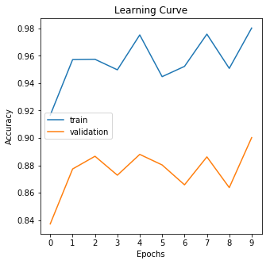

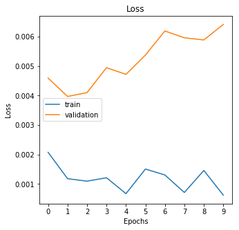

```
------------------------------------------------------------
Training with  Model2 parameters.
Training...
EPOCH 1 ...
Training Accuracy = 0.914
Training Loss = 0.00223
Validation Accuracy = 0.851
Validation Loss = 0.00472
EPOCH 2 ...
Training Accuracy = 0.927
Training Loss = 0.00196
Validation Accuracy = 0.828
Validation Loss = 0.00562
EPOCH 3 ...
Training Accuracy = 0.975
Training Loss = 0.00063
Validation Accuracy = 0.904
Validation Loss = 0.00329
EPOCH 4 ...
Training Accuracy = 0.953
Training Loss = 0.00121
Validation Accuracy = 0.873
Validation Loss = 0.00500
EPOCH 5 ...
Training Accuracy = 0.964
Training Loss = 0.00106
Validation Accuracy = 0.888
Validation Loss = 0.00507
EPOCH 6 ...
Training Accuracy = 0.977
Training Loss = 0.00065
Validation Accuracy = 0.900
Validation Loss = 0.00494
EPOCH 7 ...
Training Accuracy = 0.962
Training Loss = 0.00114
Validation Accuracy = 0.884
Validation Loss = 0.01140
EPOCH 8 ...
Training Accuracy = 0.969
Training Loss = 0.00093
Validation Accuracy = 0.893
Validation Loss = 0.00717
EPOCH 9 ...
Training Accuracy = 0.979
Training Loss = 0.00075
Validation Accuracy = 0.899
Validation Loss = 0.01152
EPOCH 10 ...
Training Accuracy = 0.960
Training Loss = 0.00128
Validation Accuracy = 0.893
Validation Loss = 0.00556

Max train accuracy:  0.978505129458 at EPOCH:  9
Max validation accuracy:  0.903628117671 at EPOCH:  3
Model saved
```

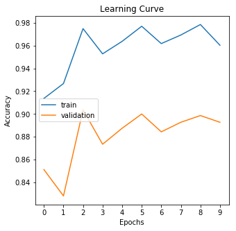

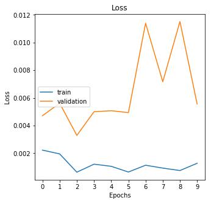

```
------------------------------------------------------------
Training with  Model3 parameters.
Training...
EPOCH 1 ...
Training Accuracy = 0.655
Training Loss = 0.00843
Validation Accuracy = 0.600
Validation Loss = 0.01011
EPOCH 2 ...
Training Accuracy = 0.846
Training Loss = 0.00392
Validation Accuracy = 0.793
Validation Loss = 0.00591
EPOCH 3 ...
Training Accuracy = 0.872
Training Loss = 0.00330
Validation Accuracy = 0.814
Validation Loss = 0.00556
EPOCH 4 ...
Training Accuracy = 0.895
Training Loss = 0.00268
Validation Accuracy = 0.814
Validation Loss = 0.00529
EPOCH 5 ...
Training Accuracy = 0.913
Training Loss = 0.00233
Validation Accuracy = 0.833
Validation Loss = 0.00490
EPOCH 6 ...
Training Accuracy = 0.866
Training Loss = 0.00368
Validation Accuracy = 0.783
Validation Loss = 0.00803
EPOCH 7 ...
Training Accuracy = 0.929
Training Loss = 0.00184
Validation Accuracy = 0.858
Validation Loss = 0.00482
EPOCH 8 ...
Training Accuracy = 0.915
Training Loss = 0.00227
Validation Accuracy = 0.821
Validation Loss = 0.00649
EPOCH 9 ...
Training Accuracy = 0.936
Training Loss = 0.00164
Validation Accuracy = 0.866
Validation Loss = 0.00473
EPOCH 10 ...
Training Accuracy = 0.939
Training Loss = 0.00155
Validation Accuracy = 0.857
Validation Loss = 0.00470

Max train accuracy:  0.938647662358 at EPOCH:  10
Max validation accuracy:  0.865986394071 at EPOCH:  9
Model saved
```

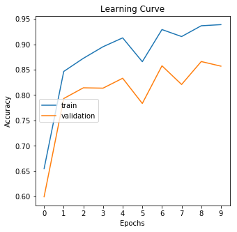

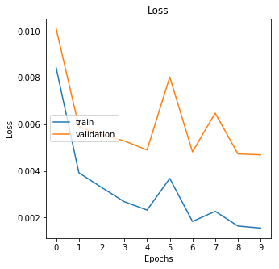

```python
import tensorflow as tf
import pathlib
from sklearn.utils import shuffle

model_data_sets =  [
             ('Model1', 'model1', 12, 32, 120, 84, False), # Conv filter doubled
             ('Model2', 'model2', 12, 32, 240, 168, False), # Conv filter + dense neurons doubled
             ('Model3', 'model3', 24, 64, 480, 336, True) # Conv filter quadrupled + dense neurons quadrupled + added 3 conv layer
            ]
nb_classes = 43
# Hyperparameters
EPOCHS = 10
BATCH_SIZE = 128
l_rate = 0.01
keep_prob_value = 1.0 # Dropout
## Parameters for random weights/bias initialization
mu = 0
sigma = 0.1

for model, save_name, filter1, filter2, neurond1, neurond2, conv3 in model_data_sets:
    pathlib.Path(save_name + '_model').mkdir(parents=True, exist_ok=True)
    save_path = save_name + '_model/' + save_name + '.ckpt'

    # Placeholder
    x = tf.placeholder(tf.float32, (None, 32, 32, 3)) # Placeholder for train dataset
    y = tf.placeholder(tf.int32, (None)) # Placeholder for labels
    one_hot_y = tf.one_hot(y, nb_classes)
    keep_prob = tf.placeholder(tf.float32) # Dropout

    # Trainig pipeline
    logits = LeNet2(x, keep_prob, mu, sigma, filter1, filter2, neurond1, neurond2, conv3 = conv3)
    cross_entropy = tf.nn.softmax_cross_entropy_with_logits(labels=one_hot_y, logits=logits)
    loss_operation = tf.reduce_mean(cross_entropy)
    optimizer = tf.train.AdamOptimizer(learning_rate = l_rate)
    training_operation = optimizer.minimize(loss_operation)

    # Model evaluation
    correct_prediction = tf.equal(tf.argmax(logits, 1), tf.argmax(one_hot_y, 1))
    accuracy_operation = tf.reduce_mean(tf.cast(correct_prediction, tf.float32))

    print('Training with ', model, 'parameters.')
    saver = tf.train.Saver()
    train_acc_all, train_loss_all, valid_acc_all, valid_loss_all = train_model(X_train_plain, y_train, X_valid_plain, y_valid, saver, save_path)
    # Plot learning curves and loss
    plot_learning(train_acc_all, valid_acc_all)
    plot_loss(train_loss_all, valid_loss_all)
    print('-'*60)
```

For now choosing first architecture with only size of both convolution filter doubled to prevent more massive overfitting. May choose bigger network after data augmentation. Since now we have a bigger model, let's try tuning some hyperparameters.  
BATCH_SIZE: 128 -> 256  
EPOCHS: 10 -> 20  
Dropout: True, 0.5 after first+second fully connected layers  
Learning rate: 0.001 -> 0.0001 -> 0.00001

```
Training with  Model1 parameters.
Training...
EPOCH 1 ...
Training Accuracy = 0.023
Training Loss = 0.01523
Validation Accuracy = 0.025
Validation Loss = 0.01593
EPOCH 2 ...
Training Accuracy = 0.029
Training Loss = 0.01487
Validation Accuracy = 0.025
Validation Loss = 0.01557
EPOCH 3 ...
Training Accuracy = 0.033
Training Loss = 0.01471
Validation Accuracy = 0.029
Validation Loss = 0.01538
EPOCH 4 ...
Training Accuracy = 0.039
Training Loss = 0.01460
Validation Accuracy = 0.032
Validation Loss = 0.01531
EPOCH 5 ...
Training Accuracy = 0.045
Training Loss = 0.01452
Validation Accuracy = 0.041
Validation Loss = 0.01519
EPOCH 6 ...
Training Accuracy = 0.049
Training Loss = 0.01444
Validation Accuracy = 0.041
Validation Loss = 0.01515
EPOCH 7 ...
Training Accuracy = 0.052
Training Loss = 0.01438
Validation Accuracy = 0.047
Validation Loss = 0.01507
EPOCH 8 ...
Training Accuracy = 0.056
Training Loss = 0.01433
Validation Accuracy = 0.050
Validation Loss = 0.01503
EPOCH 9 ...
Training Accuracy = 0.057
Training Loss = 0.01428
Validation Accuracy = 0.050
Validation Loss = 0.01504
EPOCH 10 ...
Training Accuracy = 0.060
Training Loss = 0.01424
Validation Accuracy = 0.043
Validation Loss = 0.01498
EPOCH 20 ...
Training Accuracy = 0.089
Training Loss = 0.01365
Validation Accuracy = 0.080
Validation Loss = 0.01448

Max train accuracy:  0.0888818644022 at EPOCH:  20
Max validation accuracy:  0.0800453514739 at EPOCH:  20
Model saved
```

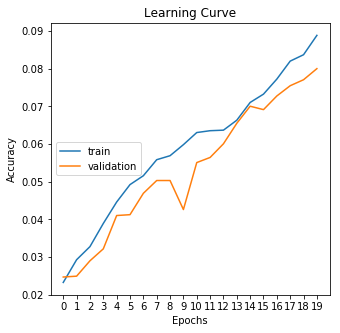

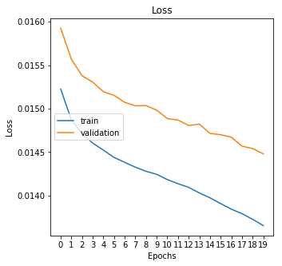

```
------------------------------------------------------------
Training with  Model2 parameters.
Training...
EPOCH 1 ...
Training Accuracy = 0.072
Training Loss = 0.01390
Validation Accuracy = 0.070
Validation Loss = 0.01474
EPOCH 2 ...
Training Accuracy = 0.155
Training Loss = 0.01272
Validation Accuracy = 0.149
Validation Loss = 0.01368
EPOCH 3 ...
Training Accuracy = 0.238
Training Loss = 0.01141
Validation Accuracy = 0.220
Validation Loss = 0.01251
EPOCH 4 ...
Training Accuracy = 0.282
Training Loss = 0.01038
Validation Accuracy = 0.261
Validation Loss = 0.01155
EPOCH 5 ...
Training Accuracy = 0.325
Training Loss = 0.00958
Validation Accuracy = 0.297
Validation Loss = 0.01066
EPOCH 6 ...
Training Accuracy = 0.365
Training Loss = 0.00887
Validation Accuracy = 0.322
Validation Loss = 0.01007
EPOCH 7 ...
Training Accuracy = 0.393
Training Loss = 0.00827
Validation Accuracy = 0.346
Validation Loss = 0.00946
EPOCH 8 ...
Training Accuracy = 0.422
Training Loss = 0.00773
Validation Accuracy = 0.378
Validation Loss = 0.00884
EPOCH 9 ...
Training Accuracy = 0.447
Training Loss = 0.00727
Validation Accuracy = 0.401
Validation Loss = 0.00851
EPOCH 10 ...
Training Accuracy = 0.471
Training Loss = 0.00683
Validation Accuracy = 0.421
Validation Loss = 0.00801
EPOCH 20 ...
Training Accuracy = 0.657
Training Loss = 0.00424
Validation Accuracy = 0.602
Validation Loss = 0.00532

Max train accuracy:  0.656628063963 at EPOCH:  20
Max validation accuracy:  0.602040816272 at EPOCH:  20
Model saved
```

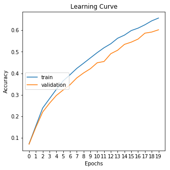

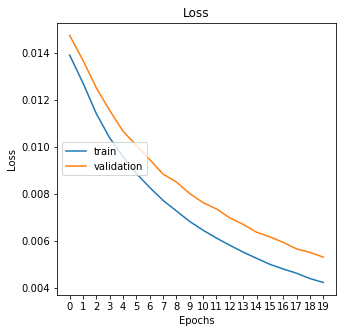

```
------------------------------------------------------------
Training with  Model3 parameters.
Training...
EPOCH 1 ...
Training Accuracy = 0.363
Training Loss = 0.00873
Validation Accuracy = 0.324
Validation Loss = 0.00971
EPOCH 2 ...
Training Accuracy = 0.569
Training Loss = 0.00542
Validation Accuracy = 0.529
Validation Loss = 0.00625
EPOCH 3 ...
Training Accuracy = 0.676
Training Loss = 0.00394
Validation Accuracy = 0.629
Validation Loss = 0.00473
EPOCH 4 ...
Training Accuracy = 0.755
Training Loss = 0.00300
Validation Accuracy = 0.708
Validation Loss = 0.00381
EPOCH 5 ...
Training Accuracy = 0.788
Training Loss = 0.00257
Validation Accuracy = 0.739
Validation Loss = 0.00339
EPOCH 6 ...
Training Accuracy = 0.826
Training Loss = 0.00210
Validation Accuracy = 0.769
Validation Loss = 0.00304
EPOCH 7 ...
Training Accuracy = 0.848
Training Loss = 0.00184
Validation Accuracy = 0.789
Validation Loss = 0.00270
EPOCH 8 ...
Training Accuracy = 0.865
Training Loss = 0.00165
Validation Accuracy = 0.804
Validation Loss = 0.00260
EPOCH 9 ...
Training Accuracy = 0.879
Training Loss = 0.00148
Validation Accuracy = 0.825
Validation Loss = 0.00232
EPOCH 10 ...
Training Accuracy = 0.888
Training Loss = 0.00139
Validation Accuracy = 0.829
Validation Loss = 0.00231
EPOCH 20 ...
Training Accuracy = 0.941
Training Loss = 0.00072
Validation Accuracy = 0.886
Validation Loss = 0.00176

Max train accuracy:  0.940831632644 at EPOCH:  20
Max validation accuracy:  0.886394557904 at EPOCH:  20
Model saved
```

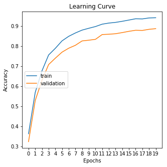

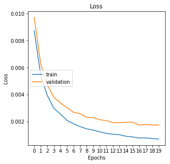

```python
import tensorflow as tf
import pathlib
from sklearn.utils import shuffle

# Adjusting learning rate
model_data_sets = [
             ('Model1', 'model1_hyper1', 0.00001),
             ('Model2', 'model1_hyper2', 0.0001),
             ('Model3', 'model1_hyper3', 0.001)
            ]
nb_classes = 43
# Hyperparameters
EPOCHS = 20
BATCH_SIZE = 256
keep_prob_value = 0.5 # Dropout
## Parameters for random weights/bias initialization
mu = 0
sigma = 0.1

for model, save_name, l_rate in model_data_sets:
    pathlib.Path(save_name + '_model').mkdir(parents=True, exist_ok=True)
    save_path = save_name + '_model/' + save_name + '.ckpt'

    # Placeholder
    x = tf.placeholder(tf.float32, (None, 32, 32, 3)) # Placeholder for train dataset
    y = tf.placeholder(tf.int32, (None)) # Placeholder for labels
    one_hot_y = tf.one_hot(y, nb_classes)
    keep_prob = tf.placeholder(tf.float32) # Dropout

    # Trainig pipeline
    logits = LeNet2(x, keep_prob, mu, sigma, 12, 32, 120, 84, conv3 = False)
    cross_entropy = tf.nn.softmax_cross_entropy_with_logits(labels=one_hot_y, logits=logits)
    loss_operation = tf.reduce_mean(cross_entropy)
    optimizer = tf.train.AdamOptimizer(learning_rate = l_rate)
    training_operation = optimizer.minimize(loss_operation)

    # Model evaluation
    correct_prediction = tf.equal(tf.argmax(logits, 1), tf.argmax(one_hot_y, 1))
    accuracy_operation = tf.reduce_mean(tf.cast(correct_prediction, tf.float32))

    print('Training with ', model, 'parameters.')
    saver = tf.train.Saver()
    train_acc_all, train_loss_all, valid_acc_all, valid_loss_all = train_model(X_train_plain, y_train, X_valid_plain, y_valid, saver, save_path)
    # Plot learning curves and loss
    plot_learning(train_acc_all, valid_acc_all)
    plot_loss(train_loss_all, valid_loss_all)
    print('-'*60)
```

Result:  
BATCH_SIZE: 256  
EPOCHS: >20  
Learning rate: 0.001  
Now that we have a nice model, let's try getting more data with augmenting the existing images. To get some inspirations, we can look at the classes/images which were classified wrong. To prevent network bias I focused on augmenting data from underpresented classes.

```
Validation Accuracy = 0.874
```

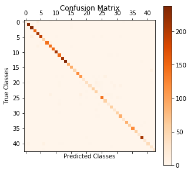

| ClassId | SignName | Train images | Validation images | Correct classified | Percent correct | Falsly classified as (ClassId) | Images falsly classified |
| --- | --- | --- | --- | --- | --- | --- | --- |
| 40 | Roundabout mandatory | 300 | 44 | 44 | 100.000000 |  |  |
| 0 | Speed limit (20km/h) | 180 | 15 | 15 | 100.000000 |  |  |
| 36 | Go straight or right | 330 | 60 | 60 | 100.000000 |  |  |
| 16 | Vehicles over 3.5 metric tons prohibited | 360 | 52 | 52 | 100.000000 |  |  |
| 14 | Stop | 690 | 90 | 90 | 100.000000 |  |  |
| 13 | Yield | 1920 | 238 | 238 | 100.000000 |  |  |
| 35 | Ahead only | 1080 | 120 | 120 | 100.000000 |  |  |
| 33 | Turn right ahead | 599 | 87 | 87 | 100.000000 |  |  |
| 9 | No passing | 1320 | 149 | 149 | 100.000000 |  |  |
| 37 | Go straight or left | 180 | 30 | 30 | 100.000000 |  |  |
| 17 | No entry | 990 | 120 | 120 | 100.000000 |  |  |
| 3 | Speed limit (60km/h) | 1260 | 150 | 149 | 99.333333 | 2 | 1 |
| 7 | Speed limit (100km/h) | 1290 | 144 | 143 | 99.305556 | 8 | 1 |
| 12 | Priority road | 1890 | 212 | 210 | 99.056604 | 18\| 40 | 1\| 1 |
| 5 | Speed limit (80km/h) | 1650 | 195 | 193 | 98.974359 | 7 | 2 |
| 10 | No passing for vehicles over 3.5 metric tons | 1800 | 213 | 210 | 98.591549 | 5\| 9\| 18 | 1\| 1\| 1 |
| 38 | Keep right | 1860 | 211 | 208 | 98.578199 | 13\| 34 | 2\| 1 |
| 34 | Turn left ahead | 360 | 60 | 59 | 98.333333 | 33 | 1 |
| 21 | Double curve | 270 | 40 | 39 | 97.500000 | 40 | 1 |
| 32 | End of all speed and passing limits | 210 | 31 | 30 | 96.774194 | 0 | 1 |
| 22 | Bumpy road | 330 | 60 | 58 | 96.666667 | 5\| 18 | 1\| 1 |
| 1 | Speed limit (30km/h) | 1980 | 239 | 230 | 96.234310 | 2\| 20\| 40 | 3\| 2\| 4 |
| 15 | No vehicles | 540 | 94 | 90 | 95.744681 | 1\| 2\| 8 | 1\| 2\| 1 |
| 25 | Road work | 1350 | 147 | 140 | 95.238095 | 5\| 20\| 21\| 22\| 23 | 2\| 2\| 1\| 1\| 1 |
| 39 | Keep left | 270 | 32 | 30 | 93.750000 | 33 | 2 |
| 11 | Right-of-way at the next intersection | 1170 | 157 | 147 | 93.630573 | 20\| 21\| 26\| 27\| 30\| 40 | 2\| 2\| 1\| 3\| 1\| 1 |
| 19 | Dangerous curve to the left | 180 | 30 | 28 | 93.333333 | 21 | 2 |
| 42 | End of no passing by vehicles over 3.5 metric ... | 210 | 30 | 28 | 93.333333 | 5\| 40 | 1\| 1 |
| 2 | Speed limit (50km/h) | 2010 | 251 | 233 | 92.828685 | 1\| 3\| 5 | 6\| 1\| 11 |
| 31 | Wild animals crossing | 690 | 95 | 88 | 92.631579 | 5\| 21\| 25 | 1\| 5\| 1 |
| 30 | Beware of ice/snow | 390 | 64 | 59 | 92.187500 | 11\| 25 | 1\| 4 |
| 8 | Speed limit (120km/h) | 1260 | 156 | 142 | 91.025641 | 0\| 7\| 24 | 1\| 5\| 8 |
| 4 | Speed limit (70km/h) | 1770 | 233 | 210 | 90.128755 | 0\| 1\| 2\| 8 | 13\| 3\| 1\| 6 |
| 20 | Dangerous curve to the right | 300 | 44 | 39 | 88.636364 | 23\| 25\| 38 | 2\| 1\| 2 |
| 18 | General caution | 1080 | 122 | 108 | 88.524590 | 20\| 24\| 25\| 27 | 1\| 10\| 1\| 2 |
| 28 | Children crossing | 480 | 68 | 60 | 88.235294 | 11\| 20\| 24\| 25\| 41 | 1\| 3\| 2\| 1\| 1 |
| 6 | End of speed limit (80km/h) | 360 | 69 | 60 | 86.956522 | 40\| 42 | 8\| 1 |
| 26 | Traffic signals | 540 | 68 | 59 | 86.764706 | 18\| 24 | 8\| 1 |
| 27 | Pedestrians | 210 | 27 | 23 | 85.185185 | 11\| 24 | 1\| 3 |
| 29 | Bicycles crossing | 240 | 33 | 27 | 81.818182 | 21\| 22 | 5\| 1 |
| 23 | Slippery road | 450 | 75 | 57 | 76.000000 | 19\| 20\| 21\| 25\| 29\| 31 | 2\| 7\| 3\| 2\| 3\| 1 |
| 41 | End of no passing | 210 | 39 | 29 | 74.358974 | 16\| 20\| 42 | 8\| 1\| 1 |
| 24 | Road narrows on the right | 240 | 16 | 6 | 37.500000 | 18\| 20\| 21\| 27\| 31 | 1\| 3\| 3\| 2\| 1 |

```python
from sklearn.metrics import confusion_matrix
import itertools

pred_list = y_valid*0
_y = tf.nn.softmax(logits=logits)
saver = tf.train.Saver()
with tf.Session() as sess:
    checkpnt = tf.train.latest_checkpoint('./model1_hyper3_model/')
    saver.restore(sess, './model1_hyper3_model/model1_hyper3.ckpt')
    valid_accuracy, b = evaluate(X_valid_plain, y_valid)
    print("Validation Accuracy = {:.3f}".format(valid_accuracy))
    for i in range(len(X_valid_plain)):
        new_img = np.expand_dims(X_valid_plain[i],0)
        prediction = sess.run([_y],feed_dict={x: new_img, keep_prob: 1.0})
        pred_list[i] = np.argmax(prediction)

# Compute confusion matrix
cnf_matrix = confusion_matrix(y_valid, pred_list)

plot_confusion_matrix(cnf_matrix)
cm_table = table_confusion_matrix(cnf_matrix)
cm_table.sort_values('Percent correct', ascending=False)
```